# cortical and subcortical correlates of face pareidolia in the macaque brain | Social Cognitive and Affective Neuroscience | Oxford Academic

### Experiment 1

#### Stimuli

A set of 56 color images of illusory faces were collected from the public domain using Google Image search (all images licensed for non-commercial reuse with modification). For each illusory face image, we also sourced a photograph of a similar object without an illusory face that matched the illusory face image as closely as possible (Figure 2A). Images were cropped to the same size (10° × 10° of visual angle). The 112 photographs were grouped into 8 unique image sets of 14 images each, with 4 illusory face sets and 4 matched object sets.

Fig. 2.

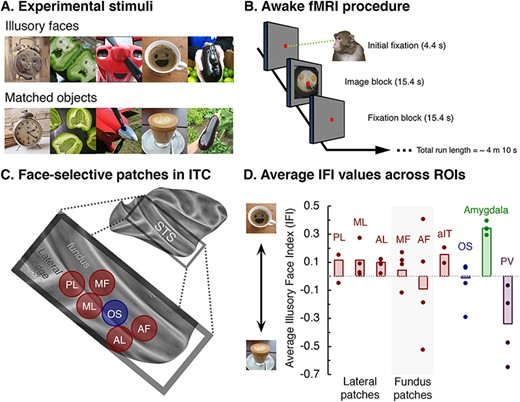

[Open in new tab](https://academic.oup.com/view-large/figure/378571890/nsac031f2.tif)Download slide

A subset of face-selective regions responds more to illusory faces than objects (Experiment 1). (A) Example stimuli from both conditions in Experiment 1. (B) Schematic of the procedure for awake fMRI experiments. While in the scanner, subjects were awake and fixating on a small fixation spot. In Experiment 1, each run began with a 4.4 s fixation period followed by 16 blocks (8 stimulation and 8 fixation blocks presented in an alternating fashion). Each block was 15.4 s long. (C) Schematic indicating the relative position of the macaque face-selective and OS patches along the STS (side view of a right hemisphere; also see Figures S1 and S2 for more details). (D) Bar graph: the median *IFI* values as a function of ROI. Dots represent individual subject medians (for results of individual subject analyses, see Table S1).

#### Experimental design and procedure

Experiment 1 used a high-powered on/off block design. Every run began with two dummy pulses and then 4.4 s of fixation before the onset of the experimental blocks. A small red fixation spot (0.5° diameter) remained on the screen for the entire duration of a run. The subjects were tasked with fixating on the red spot (within a fixation window that was 3° of visual angle in diameter). This fixation window was increased for Subject J to 4° in diameter. As long as the subjects maintained their fixation within the window, they received a juice reward approximately once every 2.2 s (±500 ms).

The 14 stimuli in each stimulus block were presented one at a time at the center of a gray screen, behind the fixation spot. The order of the stimuli in any given run was determined at random. Stimulus presentation was 900 ms with an ISI of 200 ms. Thus, all stimulation blocks were 15.4 s in duration, and each was followed by a 15.4 s fixation period (see Figure 2B). The order of the stimulation blocks was also determined at random. Each run lasted 250.8 s, during which we collected 114 volumes of data.

During the scan sessions, eye position was sampled and saved at 100 Hz. Subjects had to fixate within the fixation window for at least 60% of the run time for the data to be included in the analysis. Subject K completed 10 runs above this behavioral criterion (mean fixation = 76.5%). Subject F completed five runs (mean fixation = 85.8%). Subject S completed nine runs (mean fixation = 68.33%). Subject J only completed three runs above the behavioral criterion (mean fixation = 70%). To ensure that the results did not reflect an asymmetry in viewing behavior, for each subject we compared the number of valid eye position samples (i.e. the number of times the subject’s eye position was within the fixation window) across the two conditions (i.e. illusory faces and matched objects) using a related-samples Wilcoxon signed rank test. We used ‘run’ as the unit of analysis. In doing so, we found no evidence that the subjects behaved differently toward illusory faces than they did toward matched objects (Subject K, *N* = 10, *P* = 0.169; Subject F, *N* = 5, *P* = 0.893; Subject S, *N* = 9, *P* = 0.066; Subject J, *N* = 3, *P* = 1).

### Experiment 2

#### Stimuli

We used the 96 stimuli in Experiment 2 (32 human faces, 32 illusory faces and 32 matched objects). We used human faces rather than macaque faces to compare with illusory faces because these two face categories are better matched in terms of social relevance. Conspecific faces, even when unfamiliar to a subject, signal socially relevant cues such as dominance and social status, which are known to impact macaque behavior (Deaner *et al.*, 2005; Taubert *et al.*, 2019).

The three stimulus categories (human faces, illusory faces and matched objects) were further divided into two separate sets of images (herein referred to as Set 1 and Set 2) with 16 images in each set. Although this division was arbitrary for the human faces and the illusory faces, the objects remained matched with the corresponding illusory faces (e.g. if a green pepper with a face was allocated to ‘Set 1’, then the matched green pepper with no facial features was also allocated to ‘Set 1’).

#### Experimental design and procedure

Experiment 2 was similar to Experiment 1 except for the following details. There were 16 images per block, rather than 14, increasing the length of each block to 17.6 s. There were only 6 stimulation blocks (and 6 fixation blocks of equal length); thus, each run was 215.6 s in length during which we collected 98 volumes of data. Subjects had to fixate within the fixation window for at least 70% of the total length of a run for the data to be included in the subsequent analysis. Subject H completed 44 runs above this behavioral criterion (mean fixation = 83.43%), and Subject A completed 46 runs (mean fixation = 86%). Again, to ensure that the results did not reflect an asymmetry in viewing behavior, for each subject we compared the number of valid eye position samples across the three conditions using a Freidman test. We found no evidence that subject behavior differed across conditions (Subject H, *N* = 44, *P* = 0.913; Subject A, *N* = 46, *P* = 0.913).

### Data analysis

#### General linear model

For the data collected in Experiment 1, we convolved the hemodynamic response function following MION exposure (inverted for positive beta values) with the two regressors of interest (illusory faces and matched objects) using an ordinary least squares regression (executed using the AFNI function ‘3dDeconvolve’). The regressors of no interest included in the model were six motion regressors and three baseline estimates per run (i.e. constant, linear and quadratic). Thus, each voxel had two beta coefficients corresponding to the two regressors of interest. Statistical comparisons between face-selective voxel and OS voxel were performed using custom scripts written in MATLAB (MathWorks, version R2018b). We used the same procedure for Experiment 2, except there were three regressors of interest (illusory faces, matched objects and human faces) rather than two.

## Results (Experiment 1)

To explore the response of the cortical face patches (Figure 2C) and other face-selective regions, to illusory faces we measured brain activity during an fMRI experiment. For every voxel in the ROIs, we computed an Illusory Face Index [IFI = (β<sub>illusory faces</sub>− β<sub>objects</sub>)/(|β<sub>illusory faces</sub>|+ |β<sub>objects</sub>|)] (Taubert *et al.*, 2020b). Thus, *IFI* values greater than zero indicate that the voxel responded, on average, more to the objects with illusory facial features than the matched non-face objects. For each ROI, we used a one-sample Wilcoxon signed rank test (two-tailed) to determine whether the median *IFI* value across voxels was greater than zero (Figure 2D). This was the case for the PL (*N* = 34, *Median* = 0.11, *P* < 0.001), ML (*N* = 68, *Median* = 0.12, *P* < 0.001) and AL (*N* = 64, *Median* = 0.10, *P* < 0.001) face patches, as well as the amygdala (*N* = 405, *Median* = 0.34, *P* < 0.001). We also found evidence that voxels in the neighboring OS patch in the ITC (*N* = 60, *Median* = −0.01, *P* = 0.025), together with those in the PV face patch (*N* = 61, *Median* = −0.34, *P* < 0.001), responded consistently more to matched objects with no facial features than to objects with facial features. However, we found no evidence that the voxels in MF (*N* = 72, *Median* = 0.04, *P* = 0.079), AF (*N* = 66, *Median* = −0.09, *P* = 0.106) or aIT (*N* = 28, *Median* = 0.15, *P* = 0.111) responded differentially to objects with or without facial features.

To determine whether our results above reflected a general bias toward face-like stimuli within the visual system, we also tested a functionally defined section of EVC. For these voxels, we computed the *IFI* and then tested whether the median value was greater than zero. In contrast to when we tested some of the face patches, we found that EVC responded more to the matched objects than illusory faces (*N* = 9232, *Median* = −0.06, *P* < 0.0001). Individual subject data are reported in Figure S2. Therefore, if anything, the earlier stages of visual processing responded more to the matched objects than the illusory faces.

## Results (Experiment 2)

In Experiment 2, we measured the response of the ROIs to real faces, illusory faces and matched objects (Figure 3A). We calculated a *human face index* [*HFI* = (β<sub>human faces</sub>− β<sub>objects</sub>)/(|β<sub>human</sub> faces| + |β<sub>objects</sub>|)] and an *IFI* for all voxels in the ROIs. We analyzed each subject’s data, separately, using a mixed design 2 × 9 analysis of variance with *Index* as the repeated factor and *Region* as the group factor (the Greenhouse–Geisser correction was used for violations of sphericity). For *Subject H*, we found a main effect of *Index* (*F*[1277] = 149.28, *P* < 0.001, η*<sub>p</sub>*<sup>2</sup> = 0.35), indicating that *HFI* values (*M* = 0.37, *SEM* = 0.02) were higher than *IFI* values (*M* = 0.12, *SEM* = 0.02). The main effect of *Region* (*F*[8, 277] = 10.54, *P* < 0.001, η*<sub>p</sub>*<sup>2</sup> = 0.23) also indicated that index values differed across the ROIs. Of particular interest was the significant interaction effect between *Index* and *Region* (*F*[8, 277] = 7.53, *P* < 0.001, η*<sub>p</sub>*<sup>2</sup> = 0.18; Figure 3B). To find the source of this variation, we ran nine pairwise comparisons testing the difference between *HFI* and *IFI* values for each region of interest. We found that *HFI* values were greater than *IFI* values in the amygdala (*Mean Diff* = 0.33, *SEM* = 0.02, *P* < 0.001) and all face-selective patches (ML, *Mean Diff* = 0.3, *SEM* = 0.06, *P* < 0.001; AL, *Mean Diff* = 0.38, *SEM* = 0.07, *P* < 0.001; MF, *Mean Diff* = 0.38, *SEM* = 0.06, *P* < 0.001; AF, *Mean Diff* = 0.38, *SEM* = 0.06, *P* < 0.001; aIT, *Mean Diff* = 0.15, *SEM* = 0.06, *P* = 0.016; PV, *Mean Diff* = 0.28, *SEM* = 0.06, *P* < 0.001) except PL (*Mean Diff* = 0.005, *SEM* = 0.06, *P* = 0.942). As predicted, no such difference between *HFI* and *IFI* values was present in the OS patch (*Mean Diff* = −0.03, *SEM* = 0.06, *P* = 0.634; Figure 3B).

Fig. 3.

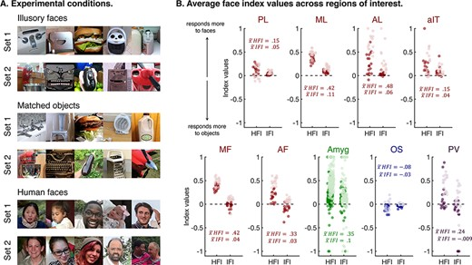

[Open in new tab](https://academic.oup.com/view-large/figure/378571912/nsac031f3.tif)Download slide

Voxel-wise response to human and illusory faces in the ROIs (Experiment 2). (A) Examples of stimuli from the six stimulus blocks in Experiment 2. (B) Plots show the HFI and the IFI for individual voxels in each region of interest (*Subject H* = light colors, *Subject A* = dark colors). Note that HFI and IFI values are plotted separately for each voxel, so that each voxel is represented twice in each subplot. Values are plotted with some jitter (*x*-axis only) for improved visualization.

The analysis of *Subject A*’s data revealed the same pattern of results as *Subject H* (*Index, F*[1, 241] = 78.85, *P* < 0.001, η*<sub>p</sub>*<sup>2</sup> = 0.25; *Region, F*[8, 241] = 6.85, *P* < 0.001, η*<sub>p</sub>*<sup>2</sup> = 0.18; *Index*Region, F*[8, 241] = 5.74, *P* < 0.001, η*<sub>p</sub>*<sup>2</sup> = 0.16; Figure 3B). Again, *HFI* values (*M* = 0.18, *SEM* = 0.02) were, on average, higher than *IFI* values (*M* = −0.01, *SEM* = 0.01). When unpacking the significant interaction between *Index* and *Region*, we found that *HFI* values were higher than *IFI* values in the amygdala (*Mean Diff* = 0.07, *SEM* = 0.03, *P* = 0.007) and all face-selective patches (ML, *Mean Diff* = 0.27, *SEM* = 0.07, *P* < 0.001; AL, *Mean Diff* = 0.22, *SEM* = 0.07, *P* = 0.001; MF, *Mean Diff* = 0.39, *SEM* = 0.07, *P* < 0.001; AF, *Mean Diff* = 0.26, *SEM* = 0.07, *P* < 0.001; PV, *Mean Diff* = 0.38, *SEM* = 0.07, *P* < 0.001) except PL (*Mean Diff* = 0.11, *SEM* = 0.07, *P* = 0.12) and aIT (*Mean Diff* = 0.14, *SEM* = 0.08, *P* = 0.057). Again, there was no difference between *HFI* and *IFI* values in the OS patch (*Mean Diff* = 0.05, *SEM* = 0.07, *P* = 0.514; Figure 3B). In sum, in both subjects, we found that the majority of cortical face patches (excluding PL in both subjects and aIT in one subject) and the amygdala responded more selectively to photographs of human faces than to photographs of face pareidolia.

### Sensitivity to illusory faces among the ROIs

We combined the *IFI* values from both subjects and computed grand median *IFI* values for each region of interest. To test whether each region responded more to illusory faces than matched objects, we used one-sample Wilcoxon signed rank tests (two-sided). In doing so, we found strong evidence that the lateral face patches in STS were all sensitive to illusory facial features in ordinary objects (PL, *N* = 33, *Median* = 0.05, *P* < 0.001; ML, *N* = 32, *Median* = 0.11, *P* < 0.001; AL, *N* = 32, *Median* = 0.06, *P* < 0.001). While we found that the aIT face patch, positioned on the ventral surface of the brain, was also sensitive to illusory facial features (*N* = 31, *Median* = 0.04, *P* < 0.001), not all of the face patches in the ITC shared this sensitivity. In fact, there was no evidence that either of the face patches seated in the fundus of the STS were sensitive to illusory facial features (MF, *N* = 32, *Median* = 0.04, *P* = 0.07; AF, *N* = 32, *Median* = 0.03, *P* = 0.93).

Interestingly, when we tested the other ROIs, we found that the OS patch responded more to objects without facial features than illusory faces (*N* = 31, *Median* = −0.03, *P* < 0.001). This result indicates the voxel suppresses its response to objects in the presence of illusory facial features (also see Figure S4). As in Experiment 1, the amygdala responded more to illusory faces then objects (*N* = 279, *Median* = 0.10, *P* < 0.001). However, we found no evidence that the PV face patch was sensitive to illusory facial features (*N* = 34, *Median* = −0.009, *P* = 0.92).

### Cross-decoding reveals a difference between cortical and subcortical mechanisms

Fig. 4.

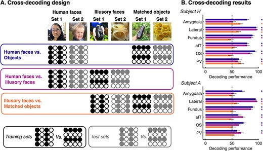

[Open in new tab](https://academic.oup.com/view-large/figure/378571919/nsac031f4.tif)Download slide

Human faces and illusory faces produce distinct activation patterns in the lateral face patches but not in the amygdala (Experiment 2). (A) Schematic of the design for three types of category cross-decoding: human faces *vs* objects, human faces *vs* illusory faces and illusory faces *vs* objects. Circles indicate example stimulus sets used for training (black) *vs* testing (gray) the classifier in each case. Note that the classifier is trained and tested on data from different stimuli (image sets) within each category (i.e. cross decoding). (B) Classifier performance for Subject H and Subject A (bottom) as a function of region (i.e. amygdala, lateral face patches, fundus face patches, aIT, OS and PV). Bar colors reflect the type of cross decoding (blue = human faces *vs* objects; pink = human faces *vs* illusory faces; orange = illusory faces *vs* matched objects). The dashed line indicates numerical chance (50%). An asterisk indicates performance is above chance (one-sample *t*-test, *P* < 0.05, see Table 1 for the results associated with the discrete face patches).

Consistent with the results of the univariate analyses in both Experiments 1 and 2, illusory faces were decodable from matched objects in the lateral edge face patches but not the fundus face patches (Figure 4B, *orange bars*). These results further indicate that, unlike the fundus face patches, the lateral face patches respond more to illusory faces than matched objects. We could not decode illusory faces from matched objects based on the patterns of activation in AM. For the amygdala, we found that illusory faces were decodable from matched objects in one subject but not the other. The same subject differences occurred for the PV patch. Although we caution against overinterpreting these results, we note that both the amygdala and the ventral lateral prefrontal cortex are multimodal regions known to respond broadly to lots of different visual stimuli (Mormann *et al.*, 2011; Romanski and Diehl, 2011; Cleeren *et al.*, 2020; Visser *et al.*, 2021). It is likely, therefore, that some of our non-face images (both illusory faces and matched objects) would have evoked strong responses from these regions making the ‘illusion faces *vs* matched objects’ decoding task more difficult. All results are available in Table 1.

Table 1.

Classifier performance (% correct)

[output not shown]

*P*-values computed using a one-sample *t*-test (two-tailed; chance = 50%).

An asterisk (*) indicates performance is above chance (i.e. *P* < 0.05, uncorrected). Bold text indicates regions where all pairwise comparisons are significant.

[Open in new tab](https://academic.oup.com/view-large/378571921)

Table 1.

Classifier performance (% correct)

[output not shown]

*P*-values computed using a one-sample *t*-test (two-tailed; chance = 50%).

An asterisk (*) indicates performance is above chance (i.e. *P* < 0.05, uncorrected). Bold text indicates regions where all pairwise comparisons are significant.

[Open in new tab](https://academic.oup.com/view-large/378571921)

Surprisingly, while decoding between human faces and illusory faces was significant in *all* cortical ROIs (including the fundus face patches), this was not the case for the face-selective amygdala region (Figure 4B, *pink bars*). This difference between the amygdala and the cortical face patches suggests that the regions of the amygdala that are sensitive to faces are also *insensitive* to the difference between human faces and illusory faces. If illusory faces are represented more similarly to human faces in the amygdala than they are in the lateral face patches, they would elicit more similar activation patterns, which in turn would make classification more difficult. We explore this idea next using representational similarity analysis.